# Probabilistic Programming in Quantitative Finance

### Thomas Wiecki

### @twiecki

# About me

- Lead Data Scientist at [Quantopian Inc](https://www.quantopian.com): Building a crowd sourced hedge fund.
- PhD from Brown University -- research on computational neuroscience and machine learning using Bayesian modeling.

# The problem we're gonna solve

Two real-money strategies:

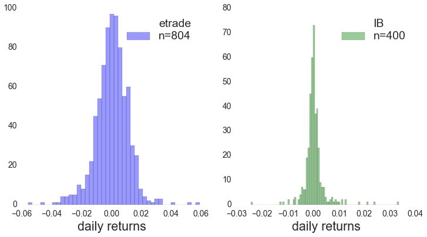

```python
plot_strats()
```

# Types of risk

[figure not shown]

# Sharpe Ratio

$$\text{Sharpe} = \frac{\text{mean returns}}{\text{volatility}}$$

```python
print "Sharpe ratio strategy etrade =", data_0.mean() / data_0.std() * np.sqrt(252)
print "Sharpe ratio strategy IB =", data_1.mean() / data_1.std() * np.sqrt(252)
```

```
Sharpe ratio strategy etrade = 0.627893606355
Sharpe ratio strategy IB = 1.43720181575
```

# Types of risk

[figure not shown]

# Short primer on random variables

- Represents our beliefs about an unknown state.
- Probability distribution assigns a probability to each possible state.
- **Not** a single number (e.g. most likely state).

[figure not shown]

- "When I bet on horses, I never lose. Why? I bet on all the horses." Tom Haverford

## You already know what a variable is...

```python
coin = 0 # 0 for tails
coin = 1 # 1 for heads
```

## A random variable assigns all possible values a certain probability

```python
coin = {0: 50%,
        1: 50%}
```

### Alternatively:

coin ~ Bernoulli(p=0.5)

- `coin` is a random variable
- `Bernoulli` is a probability distribution
- `~` reads as "is distributed as"

## This was discrete (binary), what about the continuous case?

returns ~ Normal($\mu$, $\sigma^2$)

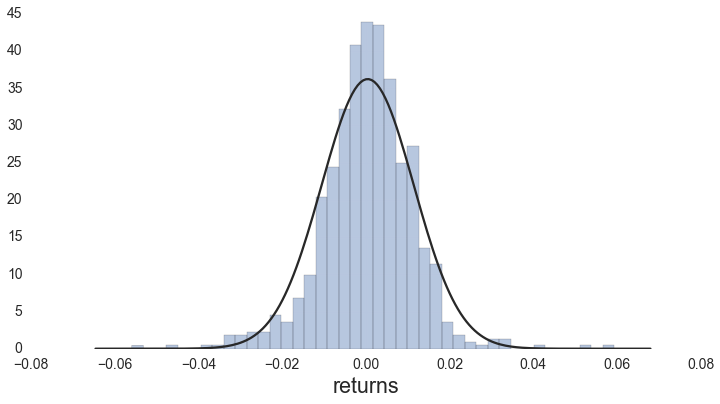

```python
from scipy import stats
sns.distplot(data_0, kde=False, fit=stats.norm)
plt.xlabel('returns')
```

# How to estimate $\mu$ and $\sigma$?

- Naive: point estimate
- Set `mu = mean(data)` and `sigma = std(data)`
- Maximum Likelihood Estimate
- Correct answer as $n \rightarrow \infty$

# Bayesian analysis

- Most of the time $n \neq \infty$...
- *Uncertainty* about $\mu$ and $\sigma$
- Turn $\mu$ and $\sigma$ into random variables
- How to estimate?

# Bayes Formula!

[figure not shown]

Use prior knowledge and data to update our *beliefs*.

[figure not shown]

```python
interactive(gen_plot, n=(0, 600), bayes=True)
```

# Probabilistic Programming

- Model **unknown causes** (e.g. $\mu$) of a phenomenon as **random variables**.
- Write a **programmatic story** of how **unknown causes** result in **observable data**.
- Use **Bayes formula** to invert generative model to infer **unknown causes**.

## Approximating the posterior with MCMC sampling

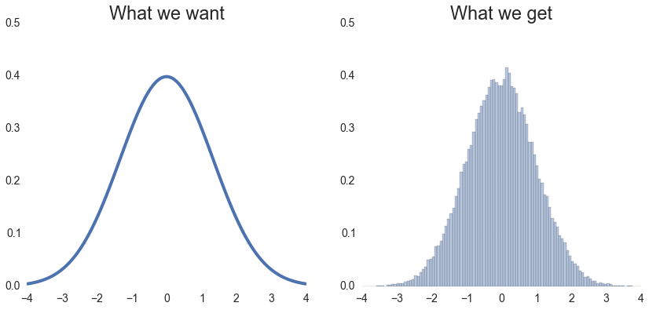

```python
plot_want_get()
```

# PyMC3

- Probabilistic Programming framework written in Python.
- Allows for construction of probabilistic models using intuitive syntax.
- Features advanced MCMC samplers.
- Fast: Just-in-time compiled by Theano.
- **Extensible**: easily incorporates custom MCMC algorithms and unusual probability distributions.
- Authors: John Salvatier, Chris Fonnesbeck, Thomas Wiecki
- Upcoming *beta* release!

[figure not shown]

# Model returns distribution: Specifying our priors

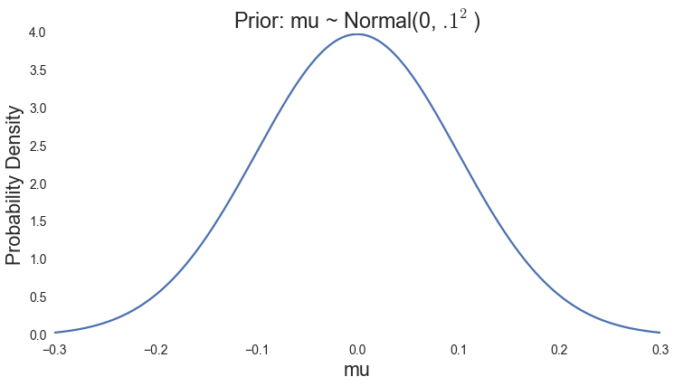

```python
x = np.linspace(-.3, .3, 500)
plt.plot(x, T.exp(pm.Normal.dist(mu=0, sd=.1).logp(x)).eval())
plt.title(u'Prior: mu ~ Normal(0, $.1^2$)'); plt.xlabel('mu'); plt.ylabel('Probability Density'); plt.xlim((-.3, .3));
```

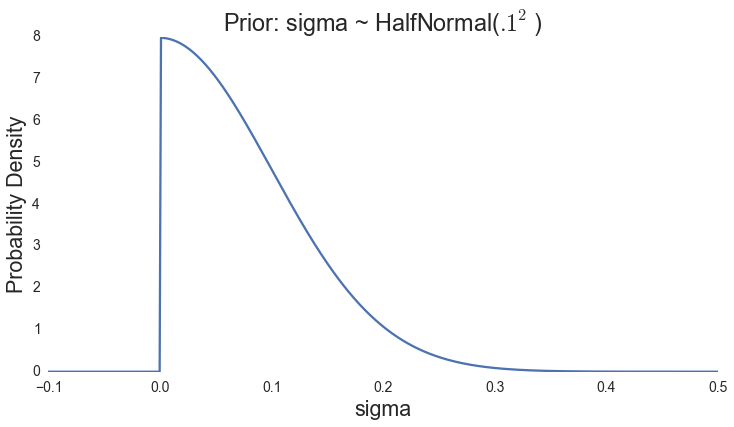

```python
x = np.linspace(-.1, .5, 500)
plt.plot(x, T.exp(pm.HalfNormal.dist(sd=.1).logp(x)).eval())
plt.title(u'Prior: sigma ~ HalfNormal($.1^2$)'); plt.xlabel('sigma'); plt.ylabel('Probability Density');
```

## Bayesian Sharpe ratio

$\mu \sim \text{Normal}(0, .1^2)$ $\leftarrow \text{Prior}$

$\sigma \sim \text{HalfNormal}(.1^2)$ $\leftarrow \text{Prior}$

$\text{returns} \sim \text{Normal}(\mu, \sigma^2)$ $\leftarrow \text{Observed!}$

$\text{Sharpe} = \frac{\mu}{\sigma}$

## Graphical model of returns

[figure not shown]

## This is what the data looks like

```python
print data_0.head()
```

```
2013-12-31 21:00:00    0.002143
2014-01-02 21:00:00   -0.028532
2014-01-03 21:00:00   -0.001577
2014-01-06 21:00:00   -0.000531
2014-01-07 21:00:00    0.011310
Name: 0, dtype: float64
```

```python
import pymc as pm

with pm.Model() as model:
    # Priors on Random Variables
    mean_return = pm.Normal('mean return', mu=0, sd=.1)
    volatility = pm.HalfNormal('volatility', sd=.1)

    # Model returns as Normal
    obs = pm.Normal('returns',
                    mu=mean_return,
                    sd=volatility,
                    observed=data_0)

    sharpe = pm.Deterministic('sharpe ratio',
                              mean_return / volatility * np.sqrt(252))
```

```python
with model:
    # Instantiate MCMC sampler
    step = pm.NUTS()
    # Draw 500 samples from the posterior
    trace = pm.sample(500, step)
```

```
 [-----------------100%-----------------] 500 of 500 complete in 0.4 sec
```

# Analyzing the posterior

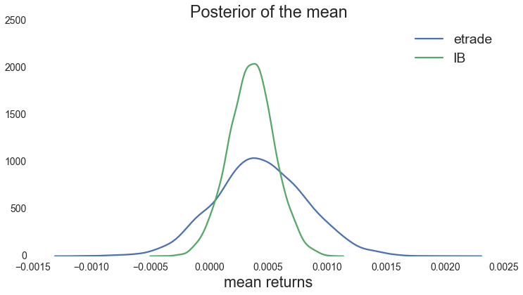

```python
sns.distplot(results_normal[0][0]['mean returns'], hist=False, label='etrade')
sns.distplot(results_normal[1][0]['mean returns'], hist=False, label='IB')
plt.title('Posterior of the mean'); plt.xlabel('mean returns')
```

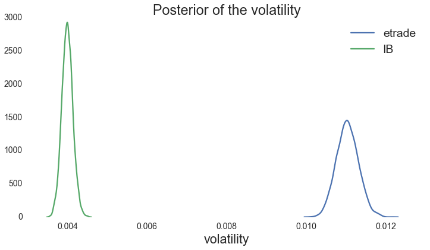

```python
sns.distplot(results_normal[0][0]['volatility'], hist=False, label='etrade')
sns.distplot(results_normal[1][0]['volatility'], hist=False, label='IB')
plt.title('Posterior of the volatility')
plt.xlabel('volatility')
```

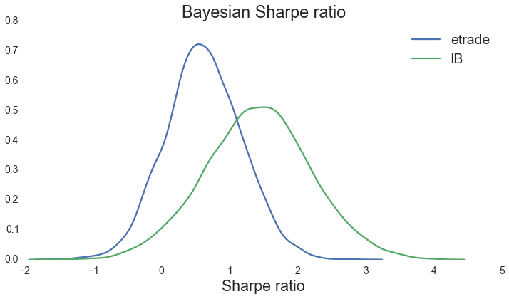

```python
sns.distplot(results_normal[0][0]['sharpe'], hist=False, label='etrade')
sns.distplot(results_normal[1][0]['sharpe'], hist=False, label='IB')
plt.title('Bayesian Sharpe ratio'); plt.xlabel('Sharpe ratio');
```

```python
print 'P(Sharpe ratio IB > 0) = %.2f%%' % \
    (np.mean(results_normal[1][0]['sharpe'] > 0) * 100)
```

```
P(Sharpe ratio IB > 0) = 96.48%
```

```python
print 'P(Sharpe ratio IB > Sharpe ratio etrade) = %.2f%%' % \
    (np.mean(results_normal[1][0]['sharpe'] > results_normal[0][0]['sharpe']) * 100)
```

```
P(Sharpe ratio IB > Sharpe ratio etrade) = 80.06%
```

# Value at Risk with uncertainty

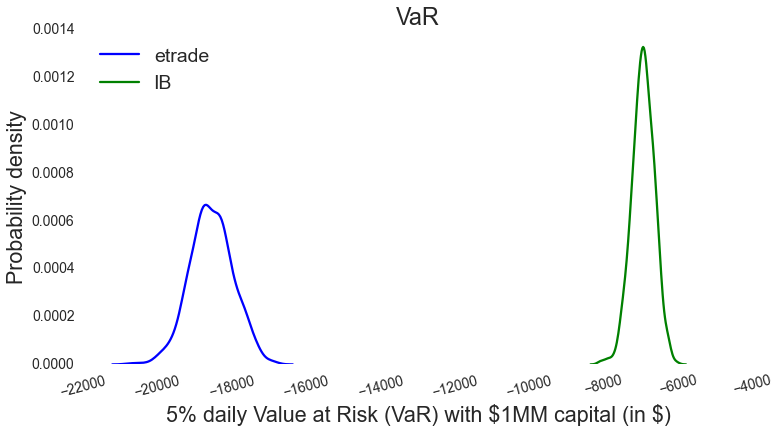

```python
ppc_etrade = post_pred(var_cov_var_normal, results_normal[0][0], 1e6, .05, samples=800)
ppc_ib = post_pred(var_cov_var_normal, results_normal[1][0], 1e6, .05, samples=800)
sns.distplot(ppc_etrade, label='etrade', norm_hist=True, hist=False, color='b')
sns.distplot(ppc_ib, label='IB', norm_hist=True, hist=False, color='g')
plt.title('VaR'); plt.legend(loc=0); plt.xlabel('5% daily Value at Risk (VaR) with \$1MM capital (in \$)'); plt.ylabel('Probability density'); plt.xticks(rotation=15);
```

# Interim summary

- **Bayesian stats** allows us to **reformulate common risk metrics**, use **priors** and **quantify uncertainty**.
- IB strategy seems better in almost every regard. Is it though?

# So far, only added confidence

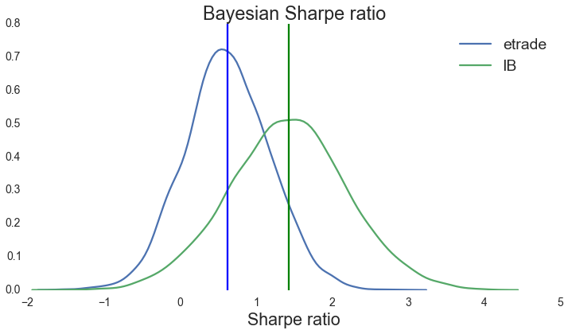

```python
sns.distplot(results_normal[0][0]['sharpe'], hist=False, label='etrade')
sns.distplot(results_normal[1][0]['sharpe'], hist=False, label='IB')
plt.title('Bayesian Sharpe ratio'); plt.xlabel('Sharpe ratio');
plt.axvline(data_0.mean() / data_0.std() * np.sqrt(252), color='b');
plt.axvline(data_1.mean() / data_1.std() * np.sqrt(252), color='g');
```

# Is this a good model?

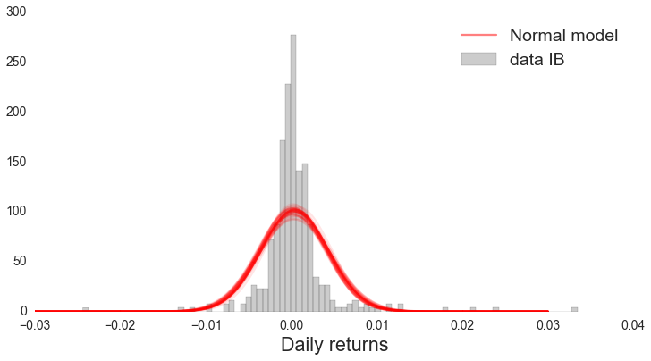

```python
sns.distplot(data_1, label='data IB', kde=False, norm_hist=True, color='.5')
for p in ppc_dist_normal:
    plt.plot(x, p, c='r', alpha=.1)
plt.plot(x, p, c='r', alpha=.5, label='Normal model')
plt.xlabel('Daily returns')
plt.legend();
```

# Can it be improved? Yes!

Identical model as before, but instead, use a heavy-tailed T distribution:

$ \text{returns} \sim \text{T}(\nu, \mu, \sigma^2)$

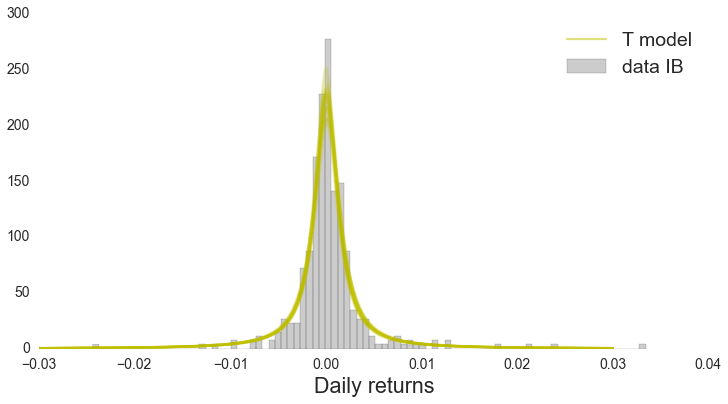

```python
sns.distplot(data_1, label='data IB', kde=False, norm_hist=True, color='.5')
for p in ppc_dist_t:
    plt.plot(x, p, c='y', alpha=.1)
plt.plot(x, p, c='y', alpha=.5, label='T model')
plt.xlabel('Daily returns')
plt.legend();
```

# Lets compare posteriors of the normal and T model

# Mean returns

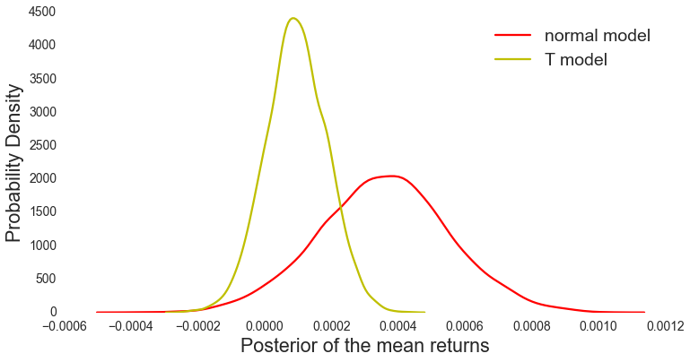

```python
sns.distplot(results_normal[1][0]['mean returns'], hist=False, color='r', label='normal model')
sns.distplot(results_t[1][0]['mean returns'], hist=False, color='y', label='T model')
plt.xlabel('Posterior of the mean returns'); plt.ylabel('Probability Density');
```

# Bayesian T-Sharpe ratio

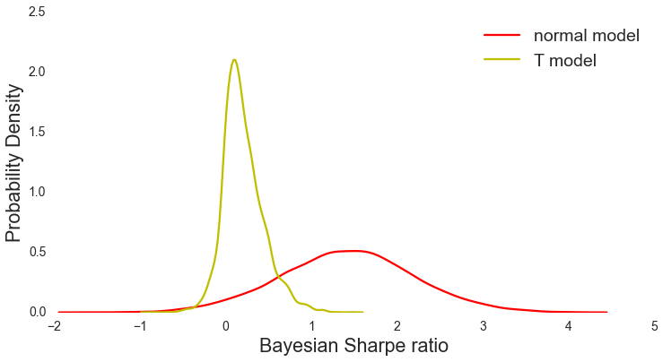

```python
sns.distplot(results_normal[1][0]['sharpe'], hist=False, color='r', label='normal model')
sns.distplot(results_t[1][0]['sharpe'], hist=False, color='y', label='T model')
plt.xlabel('Bayesian Sharpe ratio'); plt.ylabel('Probability Density');
```

# But why? T distribution is more robust!

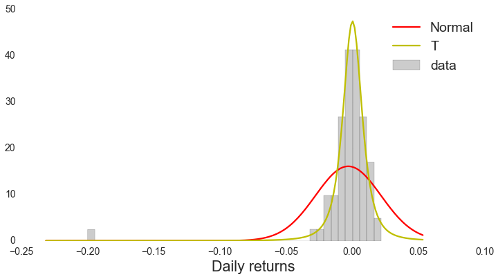

```python
sim_data = list(np.random.randn(75)*.01)
sim_data.append(-.2)
sns.distplot(sim_data, label='data', kde=False, norm_hist=True, color='.5'); sns.distplot(sim_data, label='Normal', fit=stats.norm, kde=False, hist=False, fit_kws={'color': 'r', 'label': 'Normal'}); sns.distplot(sim_data, fit=stats.t, kde=False, hist=False, fit_kws={'color': 'y', 'label': 'T'})
plt.xlabel('Daily returns'); plt.legend();
```

# Estimating tail risk using VaR

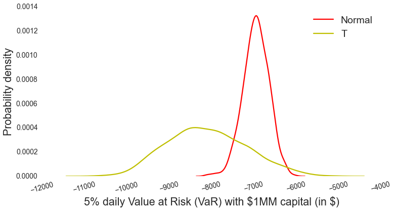

```python
ppc_normal = post_pred(var_cov_var_normal, trace_normal, 1e6, .05, samples=800)
ppc_t = post_pred(var_cov_var_t, trace_t, 1e6, .05, samples=800)
sns.distplot(ppc_normal, label='Normal', norm_hist=True, hist=False, color='r')
sns.distplot(ppc_t, label='T', norm_hist=True, hist=False, color='y')
plt.legend(loc=0); plt.xlabel('5% daily Value at Risk (VaR) with \$1MM capital (in \$)'); plt.ylabel('Probability density'); plt.xticks(rotation=15);
```

# Comparing the Bayesian T-Sharpe ratios

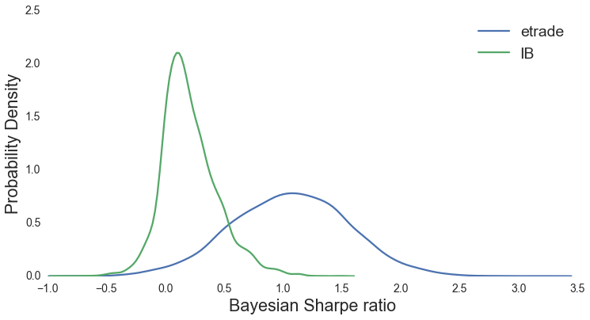

```python
sns.distplot(results_t[0][0]['sharpe'], hist=False, label='etrade')
sns.distplot(results_t[1][0]['sharpe'], hist=False, label='IB')
plt.xlabel('Bayesian Sharpe ratio'); plt.ylabel('Probability Density');
```

```python
print 'P(Sharpe ratio IB > Sharpe ratio etrade) = %.2f%%' % \
    (np.mean(results_t[1][0]['sharpe'] > results_t[0][0]['sharpe']) * 100)
```

```
P(Sharpe ratio IB > Sharpe ratio etrade) = 5.86%
```

# Conclusions

- **Bayesian statistics** allows us to **quantify uncertainty** -- measure orthogonal sources of **risk**.
- Rich statistical framework to compare different models against each other.
- **Blackbox inference algorithms** allow estimation of **complex models**.
- **PyMC3** puts **advanced samplers** at your fingertips.

# Further reading

- [Quantopian](https://www.quantopian.com) -- Develop trading algorithms like this in your browser.
- [My blog for Bayesian linear regression (financial alpha and beta)](https://twiecki.github.io)
- [Probilistic Programming for Hackers](http://camdavidsonpilon.github.io/Probabilistic-Programming-and-Bayesian-Methods-for-Hackers/) -- IPython Notebook book on Bayesian stats using PyMC2.
- [Doing Bayesian Data Analysis](http://www.indiana.edu/~kruschke/DoingBayesianDataAnalysis/) -- Great book by Kruschke.
- [PyMC3 repository](https://github.com/pymc-devs/pymc3)
- Twitter: [@twiecki](https://twitter.com/twiecki)